# Phillies Assessment pt B

### Background

In this report I have been tasked with predicting the players final batting averages for the 2018 season based upon batting data from March and April 2018. The dataset provided comes from fangraphs and includes 29 columns of information on 309 players. In the context of this study, a player's final batting average at the end of the season is the response (or dependent) variable, and the batting statistics included in the dataset constitute the independent variables.

Batting average is numeric rather than categorical, so the models will be evaluated on the R^2 and Mean Absolute Error scores. R^2 measures the percentage of variation in the response variable that is explained by the independent variables in the model. An $R^2$ goes from 0.0 to 1.0, and the closer the score is to 1.0 the more correlation it implies between the dependent and independent variables. The Mean absolute error represents the average amount each predicted final batting average differs from a player's true final batting average. Unlike the $R^2$, the closer this value is to zero, the more accurate the predictions are.

### Data

To supplement the data provided I brought in two additional datasets that I believe to be correlated to batting average. The first was statcast ball tracking data, and the second being batted ball information. These datasets are also from fangraphs, but sourced from Statcast. I filtered both datasets to include only information from March and April of the 2018 MLB season. One of the primary motivations behind including these dataset is the theory that batted ball data offers a truer indication of a players underlying skill set than a relatively small sample size of counting statistics. If the models can find a correlation between batted ball data and final batting average, it may be more predictive than factors like babip, home runs, and even current batting average which have a considerable amount of variance in just a month's worth of at bats.

The first datasource I brought in is Statcast ball tracking data. This dataset includes average exit velocity, launch angle, barrel%, hard hit%, and wOBA. These statistics are effectively measuring how hard a player hits the ball, and the quality and consistency of contact. These factors should play a role in batting average because how hard a player hits a ball and what angle the ball leaves the bat at often determines whether or not a batted ball turns into a hit or an out. Barrel and hard hit rates offer insight into how consistently a player makes quality contact. My expectation is that players who consistently make quality contact tend to produce higher batting averages.

I do, however, harbor several reservations about the effectiveness of this dataset. Statistics like launch angle and exit velocity are extremely predictive of the outcome of an individual batted ball, but averaged over the course of many at bats may not reveal much. Players like Joey Gallo have high strikeout rates but tend to crush the ball when they make contact. Such players likely have high average exit velocities and launch angles but still have poor batting averages. It may also punish high contact players who put the ball in play more often but may make weaker contact. Their exit velocity and launch angle would be subsequently suppressed when looked at on average, but putting the ball in play more often leads to more chances to get a hit.

The second dataset I brought in was Fangraphs batted ball data. This includes pull%, center%, opposite%, soft%, med%, and hard%. This represents where each batter tends to hit the ball, and how hard they hit it. With the adoption of the shift and extreme pull hitting fly ball batting approaches, attempting to hit to contact and spray the ball around the field is becoming more or a lost art in baseball. It intuitively makes sense that players with a more even distribution on where they hit the ball tend to have a higher batting average. The soft%, medium% and hard% try to measure how hard a player tends to hit the ball. This may overlap with exit velocity and hard hit rate, but it also goes into more detail about the consistency with which a player makes good contact.

### Preprocessing and Data Exploration

After merging the two external dataset, I needed to prepare the dataset for modeling. The data had no missing values for any of the observations. Almost all of the new columns I brought in from the new dataset required formatting because they were stored as percentage strings. I cleaned these columns and reformatted them as decimals.

I had several takeaways from my data exploration. As batting averages are calculated from at bats, one of my concerns was the amount of variance observations with few plate appearances might cause within the model. The number of plate appearances spanned from a minimum of 22 to a maximum of 125. This constitutes a relatively wide range, my concern was that the model would treat these observations as equal when looking at the relationship between their independent and dependent variables when in reality certain observations have a much larger sample size for their underlying metrics and batting average to smooth out. Because of this, I identified a linear regression weighted by the number of bats as one of the models I would like to look at when creating my predictions. The graph below shows the distribution of at bats per player in the dataset.

```
[]
```

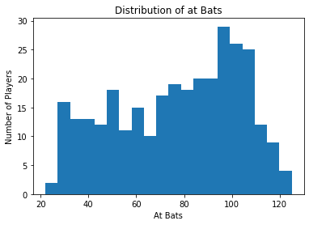

```python
import matplotlib.pyplot as plt

#
plt.hist(df.MarApr_AB, bins = 20)
plt.xlabel('At Bats')
plt.ylabel('Number of Players')
plt.title('Distribution of at Bats')

plt.plot()
```

Most of these columns are likely to have little to no predictive power on full season batting average, but their mere presence can lead to the modeling picking up any noise from them and mistakenly attributing significance to it in the model. This noise will actually improve the $R^2$ score and Mean Absolute Error of the model fit and tested on this specific dataset, but having these unimportant variables makes it less likely it will effectively translate to predictioning test datasets. Because of this, I dropped several columns that I feel confident should not have any predictive signal on a player's batting average. These columns were PlayerID, Name, Team, Runs, RBI’s, and stolen bases. After removing these, there are 34 total independent variables remaining in the model. This is still significantly too many variables for the size of the dataset. To deal with the problems of overfitting and multicollinearity, I decided I would also test a Lasso regression, and other models that introduce a normalization penalty.

### Modeling

Linear regression is perhaps the simplest and least sexy model in Data science, but it is often the most effective in situations where the response variable is continuous and numeric. I tried four different iterations of a linear regression using the SciKitLearn library for python.

> 1. Linear Regression on just the default dataset provided - Although I do believe that the datasets I added contain useful information, I wanted to make sure that the default dataset did not lead to a better model. I am concerned about overfitting the model due to the number of dependent variables in the columns, and by adding over ten more columns I could have created an even bigger problem
> 2. Linear Regression on the entire dataset I created including the statcast and batted ball data.
> 3. Linear Regression weighted by number of at bats - The SciKitLearn Linear Regression model allows you to weigh particular observations more when fitting a model. In our dataset each observation represents one player's statistics. But since the number of at bats, each player has a different number of observations making up their statistics going into the model. Because of this, I believe it could be useful to give extra weight to the players with more at bats making up their statistics because it offers a larger sample size.
> 4. Lasso Linear Regression - Lasso linear regression uses an L1 penalty on model coefficients to shrink the slope of certain variables, and in some cases removes them from the model entirely. The strength of the regularization penalty is determined by the Lambda value. To find the optimal lambda value leading to the optimized score in my Lasso model, I used the SKlearn random search package, which randomly goes through a list of designated parameters you want to optimize and reports back which set of parameters performed best.

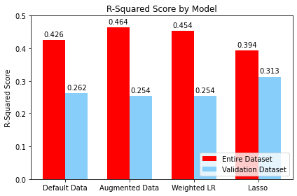

```python
##### Plot R-Squared Scores

x = np.arange(len(lrLabel))  # the label locations
width = 0.35  # the width of the bars

fig, ax = plt.subplots()
rects1 = ax.bar(x - width/2, lrR, width, label='Entire Dataset', color = 'red')
rects2 = ax.bar(x + width/2, lrValidationR, width, label='Validation Dataset', color = 'lightskyblue')

# Add some text for labels, title and custom x-axis tick labels, etc.
ax.set_ylabel('R-Squared Score')
ax.set_title('R-Squared Score by Model')
ax.set_xticks(x)
ax.set_xticklabels(lrLabel)
ax.set_ylim(0, 0.5)
ax.legend(loc='lower right')


def autolabel(rects):
    """Attach a text label above each bar in *rects*, displaying its height."""
    for rect in rects:
        height = rect.get_height()
        ax.annotate('{}'.format(height),
                    xy=(rect.get_x() + rect.get_width() / 2, height),
                    xytext=(0, 3),  # 3 points vertical offset
                    textcoords="offset points",
                    ha='center', va='bottom')


autolabel(rects1)
autolabel(rects2)


fig.tight_layout()

plt.show()
```

Unsurprisingly, the augmented dataset with the statcast and batted ball data performed best on the training data. Having more columns almost always leads to better training data performance. However this model had the worst performance on the test data. This is almost surely a sign that the model was significantly overfit. As I hypothesized in my initial data exploration, the Lasso regression performed best on the test data by a fairly significant margin. The model achieved an $R^2$ score of .313 on the validation data, significantly better than the second best score of .262. The Lasso model performed worse on the training data as expected because the normalization penalty generally sacrifices an increase in bias for a decrease in variance. The mean absolute error scores follow the same trend as the $R^2$ scores, but are significantly closer to one another. In the context of this study, an $R^2$ of .313 means that 31% of the variance in a player's final batting average can be explained by the variables in this model.

I tested several additional models to see how they performed on the dataset. They included:

> 1. Random Forest Regressor - Random forest regressors construct decision trees while training the data. In the context of this study the model is looking for players with similar statistical profiles, grouping similar players and taking the average of each group's final batting average and using this as the prediction.
> 2. Support Vector Regressor (SVR) - The support vector regressor applies an L2 normalization penalty on the data. It does this by creating an acceptable margin of error rather, and attempting to minimize the error only for data points that fall outside the acceptable error margin. This helps to prevent the model from reacting to random noise in the dataset and avoid overfitting. Since its goal is not to minimize overall error in the training data, it generally performs worse on training data relative to most other models, but translates well to test data if the training data is noisy.
> 3. Gradient Boosting Regressor - Gradient boosting functions similarly to the random forest classifier. They differ in that gradient boosted regressors use a collection of less complex trees with high bias and low variance and attempt to minimize bias in these trees. Conversely, decision trees build a complex decision tree that is naturally low bias and high variance and attempt to minimize the variance.

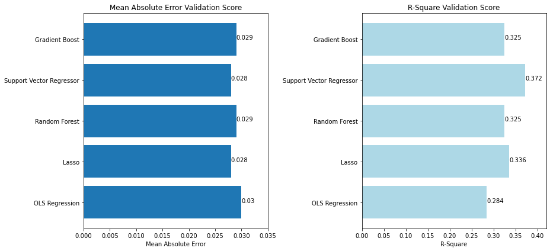

```python
fig, axs = plt.subplots(1,2,figsize=(13,6))

axs[0].barh(labels, rmse_val1)
axs[0].set_xlim(0, 0.035)


for index, value in enumerate(rmse_val1):
    axs[0].text(value, index,  str(value))


axs[1].barh(labels, score_list, color = 'lightblue')
axs[1].set_xlim(0, 0.42)


for index, value in enumerate(score_list):
    axs[1].text(value, index,
             str(value))

axs[0].set(xlabel= 'Mean Absolute Error', title='Mean Absolute Error Validation Score')
axs[1].set(xlabel= 'R-Square', title='R-Square Validation Score')

plt.tight_layout()


plt.show()
```

The Support Vector Regressor performs best because it avoids overfitting to the training data. The inclusion of an acceptable margin of error and focusing on minimizing the error of the data points falling outside of that margin means that the model is not as susceptible to the noise and randomness of data in the model. Having this margin acts as a built in regularization penalty. The inclusion of so many independent variables in this model leads to a lot of noise, the support vector is able to compensate for this and produce strong test predictions.

### Conclusion

The results show a continuation of the trend that the normalized more biased models are doing best on the test data. From the initial data analysis, my biggest concern was the number of independent variables relative to the number of total observations would lead to overfitting. This played out in the modeling. Ultimately the two models that performed best - Lasso regression and Support Vector regression - were the models that included regularization penalties to reduce the amount of noise in the dataset.

If the number of independent variables was causing problems, it may raise the question of why I did not prune back the number of variables in the data set I trained on?

The simple answer is that I did try this. I had several iterations of datasets that contained a significantly reduced number of columns, and while these did help the test scores of some of the simple linear regressions and random forest regressor, their scores still did not come close to the performance of the Lasso and SVR models. The problem with this approach is that we do not know which variables have the most predictive signal. Additionally, we do not know if one variable that appears to have little predictive ability on its own works well in tandem with another variable to boost the overall predictive power of the model. The SVR and Lasso models are able to answer these questions for us and tell us what combination of variables work best, and which variables should be excluded.

An important consideration when reflecting on the results of this study is what the purpose behind it is. If the question had been rephrased to “What factors in the dataset predict batting average”, the report would change significantly. Rather than focusing on models that generated the best overall prediction scores, I would focus on model interpretability. This would include focusing on the model assumptions to ensure they were met, and looking at the significance of the individual factors in the dataset. The results of a study like that would be more focused on the individual variables that have strong correlation with batting average rather than the overall MAE and $R^2$ of the models.

### Final Batting Average Predictions

```python
pd.set_option('display.max_rows', final.shape[0]+1)
print(final)
```

```
     playerid                  Name  Predictions
0       11680            Elias Diaz     0.292925
1       12161       Xander Bogaerts     0.292431
2       10816           Jedd Gyorko     0.260030
3       13611          Mookie Betts     0.287350
4       11493         Manny Machado     0.305780
5        6012        Didi Gregorius     0.285219
6       11739         J.T. Realmuto     0.279354
7       11738  Christian Villanueva     0.265056
8       11205            Adam Eaton     0.279949
9       12927         Brandon Nimmo     0.263948
10      14145      Daniel Robertson     0.271082
11      14274         Mitch Haniger     0.270699
12      19755         Shohei Ohtani     0.278276
13      13066     Teoscar Hernandez     0.285200
```

[output cut: 295 more lines]

### Code Appendix

###### Cleaning, EDA, Merging

```python
import pandas as pd
import numpy as np
from sklearn.model_selection import cross_val_score
from sklearn.model_selection import train_test_split
from sklearn.model_selection import cross_val_score
from sklearn import metrics
import matplotlib.pyplot as plt
from sklearn.model_selection import ShuffleSplit
```

```python
### Data import merging and cleaning

# Import Data
fg = pd.read_csv('/Users/caleboneel/Downloads/batting.csv')
statcast = pd.read_csv('/Users/caleboneel/Downloads/FanGraphsSC.csv')
battedball = pd.read_csv('/Users/caleboneel/Downloads/FanGraphsBB.csv')


# Consolidate new datasets into just data columns we are interested in to make merge cleaner
statcast = statcast[['playerid', 'EV', 'maxEV', 'LA', 'Barrel%', 'HardHit%', 'wOBA']]
battedball = battedball[['playerid', 'Pull%', 'Cent%', 'Oppo%', 'Soft%', 'Med%', 'Hard%']]

# Merge Datasets
df = fg.merge(statcast, how = 'left', on='playerid')
df = df.merge(battedball, how = 'left', on='playerid')
df.head(5)
```

|  | playerid | Name | Team | MarApr_PA | MarApr_AB | MarApr_H | MarApr_HR | MarApr_R | MarApr_RBI | MarApr_SB | ... | LA | Barrel% | HardHit% | wOBA | Pull% | Cent% | Oppo% | Soft% | Med% | Hard% |
| --- | --- | --- | --- | --- | --- | --- | --- | --- | --- | --- | --- | --- | --- | --- | --- | --- | --- | --- | --- | --- | --- |
| 0 | 11680 | Elias Diaz | Pirates | 34 | 31 | 15 | 2 | 6 | 6 | 0 | ... | 3.2 | 7.1% | 42.9% | 0.517 | 39.3% | 39.3% | 21.4% | 17.9% | 64.3% | 17.9% |
| 1 | 12161 | Xander Bogaerts | Red Sox | 54 | 51 | 21 | 3 | 8 | 15 | 0 | ... | 15.2 | 18.6% | 41.9% | 0.486 | 46.5% | 34.9% | 18.6% | 11.6% | 60.5% | 27.9% |
| 2 | 10816 | Jedd Gyorko | Cardinals | 30 | 22 | 8 | 2 | 5 | 5 | 1 | ... | 19.6 | 11.8% | 35.3% | 0.485 | 58.8% | 29.4% | 11.8% | 11.8% | 52.9% | 35.3% |
| 3 | 13611 | Mookie Betts | Red Sox | 107 | 90 | 31 | 8 | 29 | 18 | 3 | ... | 22.2 | 20.3% | 51.9% | 0.481 | 50.6% | 32.9% | 16.5% | 12.7% | 38.0% | 49.4% |
| 4 | 11493 | Manny Machado | Orioles | 125 | 108 | 39 | 9 | 14 | 22 | 2 | ... | 16.2 | 15.2% | 47.8% | 0.464 | 33.7% | 39.1% | 27.2% | 22.8% | 46.7% | 30.4% |

5 rows × 41 columns

```python
# Check for missing Values
print(df.isnull().any())
```

```
playerid             False
Name                 False
Team                 False
MarApr_PA            False
MarApr_AB            False
MarApr_H             False
MarApr_HR            False
MarApr_R             False
MarApr_RBI           False
MarApr_SB            False
MarApr_BB%           False
MarApr_K%            False
MarApr_ISO           False
MarApr_BABIP         False
MarApr_AVG           False
MarApr_OBP           False
MarApr_SLG           False
MarApr_LD%           False
MarApr_GB%           False
MarApr_FB%           False
MarApr_IFFB%         False
MarApr_HR/FB         False
MarApr_O-Swing%      False
MarApr_Z-Swing%      False
MarApr_Swing%        False
MarApr_O-Contact%    False
MarApr_Z-Contact%    False
MarApr_Contact%      False
FullSeason_AVG       False
EV                   False
maxEV                False
LA                   False
Barrel%              False
HardHit%             False
wOBA                 False
Pull%                False
Cent%                False
Oppo%                False
Soft%                False
Med%                 False
Hard%                False
dtype: bool
```

```python
# Convert all percent strings to floats
df['HardHit%'] = df['HardHit%'].str.rstrip('%').astype('float') / 100.0
df['Pull%'] = df['Pull%'].str.rstrip('%').astype('float') / 100.0
df['Barrel%'] = df['Barrel%'].str.rstrip('%').astype('float') / 100.0
df['Cent%'] = df['Cent%'].str.rstrip('%').astype('float') / 100.0
df['Oppo%'] = df['Oppo%'].str.rstrip('%').astype('float') / 100.0
df['Soft%'] = df['Soft%'].str.rstrip('%').astype('float') / 100.0
df['Med%'] = df['Med%'].str.rstrip('%').astype('float') / 100.0
df['Hard%'] = df['Hard%'].str.rstrip('%').astype('float') / 100.0
```

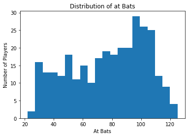

```python
# Plot distribution of AB's
plt.hist(df.MarApr_AB, bins = 20)
plt.xlabel('At Bats')
plt.ylabel('Number of Players')
plt.title('Distribution of at Bats')
```

```python
# Turn full season average into the response variable for test train validation, drop from independent variable list
y = df['FullSeason_AVG']
X = df.drop(['FullSeason_AVG', 'playerid', 'Name', 'Team'
            ,'MarApr_R','MarApr_RBI', 'MarApr_SB'], axis=1)

# Baseline Dataset
default = fg
y_ols = default['FullSeason_AVG']
X_ols = default.drop(['FullSeason_AVG', 'playerid', 'Name', 'Team'], axis=1)

# Split the Data
X_train, X_test, y_train, y_test = train_test_split(X, y, test_size=0.20, random_state=50)
```

#### Modeling - Regression

```python
from sklearn.ensemble import RandomForestRegressor
from sklearn.ensemble import GradientBoostingRegressor
from sklearn.neighbors import NearestNeighbors
from sklearn import svm
from sklearn.metrics import precision_recall_curve
from sklearn import metrics
from sklearn.metrics import mean_squared_error
from math import sqrt
```

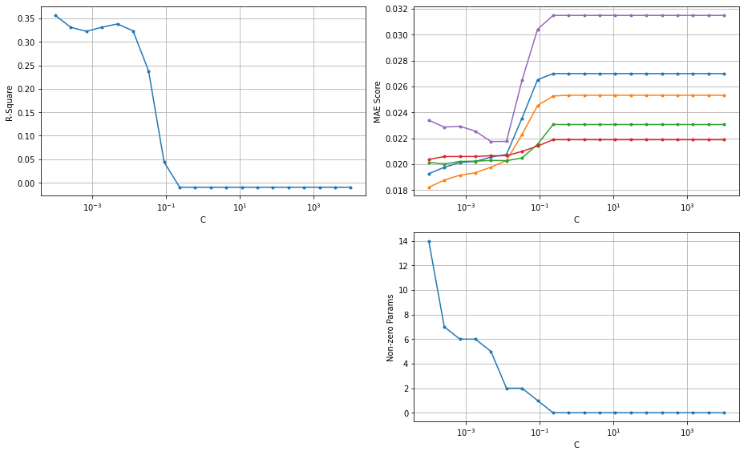

```python
#### Lasso Optimization and Visualization ####

from sklearn.metrics import log_loss, f1_score, roc_curve, auc
from tqdm import tqdm
from sklearn import linear_model
from sklearn.model_selection import RepeatedKFold
from numpy import absolute

def lasso_mod(alpha):
    lr = linear_model.Lasso(alpha=alpha)
    lr.fit(X_train, y_train)
    return lr

non_zero = []
rsquare_list = []
score_list = []
c_param = np.logspace(-4,4,20)

# Iterate over the regularization coefficient, C
for c in tqdm(c_param):
    lr = lasso_mod(c)


    # number of non-zero params
    coefs = np.sum(lr.coef_ != 0)
    non_zero.append(coefs)

    # R-square
    rsquare_list.append(lr.score(X_test, y_test))


    # MAE score
    pred = lr.predict(X_test)
    scores = cross_val_score(lr, X, y, scoring='neg_mean_absolute_error', n_jobs=-1)
    scores = absolute(scores)
    score_list.append(scores)



# Graph the Data
plt.figure(figsize=(13, 8))

# Cost Function
plt.subplot(221)
plt.plot(c_param, rsquare_list, marker='.')
plt.grid(True)
plt.xlabel('C')
plt.ylabel('R-Square')
plt.xscale('log')
plt.tick_params(axis='y', which='minor')

# MAE Score
plt.subplot(222)
plt.plot(c_param, score_list, marker='.')
plt.grid(True)
plt.xlabel('C')
plt.ylabel('MAE Score')
plt.xscale('log')


# Plot Nonzero Params
plt.subplot(224)
plt.plot(c_param, non_zero, marker='.')
plt.grid(True)
plt.xlabel('C')
plt.ylabel('Non-zero Params')
plt.xscale('log')

plt.tight_layout()
plt.show()
```

```python
#### LASSO RANDOM SEARCH OPTIMIZATION ####

from sklearn.model_selection import GridSearchCV, RandomizedSearchCV
from time import time
import scipy.stats as stats
from sklearn.utils.fixes import loguniform


# Create MLP model with desired parameters, omitting the ones we will use random search to find
clf = linear_model.Lasso()
kfold = RepeatedKFold(n_splits=10, n_repeats=3, random_state=1)

# A function to print results of random search
def report(results, n_top=3):
    for i in range(1, n_top + 1):
        candidates = np.flatnonzero(results['rank_test_score'] == i)
        for candidate in candidates:
            print("Model with rank: {0}".format(i))
            print("Mean validation score: {0:.3f} (std: {1:.3f})"
                  .format(results['mean_test_score'][candidate],
                          results['std_test_score'][candidate]))
            print("Parameters: {0}".format(results['params'][candidate]))
            print("")

# specify parameters and distributions to sample from
param_dist = {
              'alpha': loguniform(1e-10, 1e2),
           }

# run randomized search
n_iter_search = 50
random_search = RandomizedSearchCV(clf, param_distributions=param_dist, cv=kfold, n_jobs=-1,
                                   n_iter=n_iter_search, verbose=1).fit(X,y)

# Time and output results of random search model
start = time()
random_search.fit(X, y)
print("RandomizedSearchCV took %.2f seconds for %d candidates"
      " parameter settings." % ((time() - start), n_iter_search))
report(random_search.cv_results_)
```

```
Fitting 30 folds for each of 50 candidates, totalling 1500 fits
```

```
[Parallel(n_jobs=-1)]: Using backend LokyBackend with 4 concurrent workers.
[Parallel(n_jobs=-1)]: Done 280 tasks      | elapsed:    1.2s
[Parallel(n_jobs=-1)]: Done 1500 out of 1500 | elapsed:    5.3s finished
[Parallel(n_jobs=-1)]: Using backend LokyBackend with 4 concurrent workers.
```

```
Fitting 30 folds for each of 50 candidates, totalling 1500 fits
```

```
[Parallel(n_jobs=-1)]: Done 312 tasks      | elapsed:    1.2s
```

```
RandomizedSearchCV took 4.77 seconds for 50 candidates parameter settings.
Model with rank: 1
Mean validation score: 0.313 (std: 0.142)
Parameters: {'alpha': 0.00019425131971719884}

Model with rank: 2
Mean validation score: 0.312 (std: 0.142)
Parameters: {'alpha': 0.00024799861633536955}

Model with rank: 3
Mean validation score: 0.311 (std: 0.143)
Parameters: {'alpha': 0.0001532394142271856}
```

```
[Parallel(n_jobs=-1)]: Done 1500 out of 1500 | elapsed:    4.8s finished
```

```python
#####  COMPARING ALL REGRESSION MODELS

lrLabel = ['Default Data', 'Augmented Data', 'Weighted LR', 'Lasso']
lrMAE = []
lrR = []
lrValidationMAE = []
lrValidationR = []

cv = RepeatedKFold(n_splits=10, n_repeats=3, random_state=1)



####### Default Dataset Linear Regression #######

# R-Square Entire Dataset
from sklearn.linear_model import LinearRegression
default = LinearRegression().fit(X_ols, y_ols)
lrR.append(round(default.score(X_ols, y_ols), 3))

# MAE Entire Dataset
pred=default.predict(X_ols)
error = sqrt(mean_squared_error(y_ols,pred))
lrMAE.append(round(error, 3))

# R-Square Validation
defaultRsqCV = cross_val_score(default, X_ols, y_ols, scoring='r2', cv=cv, n_jobs=-1)
lrValidationR.append(round(sum(defaultRsqCV)/len(defaultRsqCV), 3))

# MAE Validation
defaultCV = cross_val_score(default, X_ols, y_ols, scoring='neg_mean_absolute_error', cv=cv, n_jobs=-1)
defaultCV = absolute(defaultCV)
lrValidationMAE.append(round(sum(defaultCV)/len(defaultCV), 3))




###### Augmented Dataset Linear Regression ########

# R-Square Entire Dataset
augment = LinearRegression().fit(X, y)
lrR.append(round(augment.score(X, y), 3))

# MAE Entire Dataset
pred = augment.predict(X)
error = sqrt(mean_squared_error(y,pred))
lrMAE.append(round(error, 3))

# R-Square Validation
AugmentRsqCV = cross_val_score(augment, X, y, scoring='r2', cv=cv, n_jobs=-1)
lrValidationR.append(round(sum(AugmentRsqCV)/len(AugmentRsqCV), 3))

# MAE Validation
augmentCV = cross_val_score(augment, X, y, scoring='neg_mean_absolute_error', cv=cv, n_jobs=-1)
augmentCV = absolute(augmentCV)
lrValidationMAE.append(round(sum(augmentCV)/len(augmentCV), 3))




###### Weighted Linear Regression ########

# R-Square Entire Dataset
weighted = LinearRegression().fit(X, y, sample_weight = X['MarApr_AB'])
lrR.append(round(weighted.score(X, y), 3))

# MAE Entire Dataset
pred = weighted.predict(X)
error = sqrt(mean_squared_error(y,pred))
lrMAE.append(round(error, 3))

# R-Square Validation
WeightedRsqCV = cross_val_score(weighted, X, y, scoring='r2', cv=cv, n_jobs=-1)
lrValidationR.append(round(sum(WeightedRsqCV)/len(WeightedRsqCV), 3))

# MAE Validation
WeightedCV = cross_val_score(weighted, X, y, scoring='neg_mean_absolute_error', cv=cv, n_jobs=-1)
WeightedCV = absolute(WeightedCV)
lrValidationMAE.append(round(sum(WeightedCV)/len(WeightedCV), 3))



###### Lasso Regression ########

# R-Square Entire Dataset
#lasso = linear_model.Lasso(alpha=0.00252).fit(X, y)
lasso = linear_model.Lasso(alpha=0.0002268128333327706).fit(X, y)
lrR.append(round(lasso.score(X, y), 3))

# MAE Entire Dataset
pred = lasso.predict(X)
error = sqrt(mean_squared_error(y,pred))
lrMAE.append(round(error, 3))

# R-Square Validation
lassoRsqCV = cross_val_score(lasso, X, y, scoring='r2', cv=cv, n_jobs=-1)
lrValidationR.append(round(sum(lassoRsqCV)/len(lassoRsqCV), 3))

# MAE Validation
lassoCV = cross_val_score(lasso, X, y, scoring='neg_mean_absolute_error', cv=cv, n_jobs=-1)
lassoCV = absolute(lassoCV)
lrValidationMAE.append(round(sum(lassoCV)/len(lassoCV), 3))
```

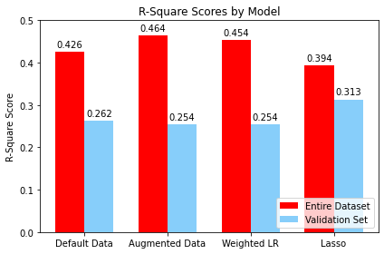

```python
##### Plot R-Squared Scores

x = np.arange(len(lrLabel))  # the label locations
width = 0.35  # the width of the bars

fig, ax = plt.subplots()
rects1 = ax.bar(x - width/2, lrR, width, label='Entire Dataset', color = 'red')
rects2 = ax.bar(x + width/2, lrValidationR, width, label='Validation Set', color = 'lightskyblue')

# Add some text for labels, title and custom x-axis tick labels, etc.
ax.set_ylabel('R-Square Score')
ax.set_title('R-Square Scores by Model')
ax.set_xticks(x)
ax.set_xticklabels(lrLabel)
ax.set_ylim(0, 0.5)
ax.legend(loc='lower right')


def autolabel(rects):
    """Attach a text label above each bar in *rects*, displaying its height."""
    for rect in rects:
        height = rect.get_height()
        ax.annotate('{}'.format(height),
                    xy=(rect.get_x() + rect.get_width() / 2, height),
                    xytext=(0, 3),  # 3 points vertical offset
                    textcoords="offset points",
                    ha='center', va='bottom')


autolabel(rects1)
autolabel(rects2)


fig.tight_layout()

plt.show()
```

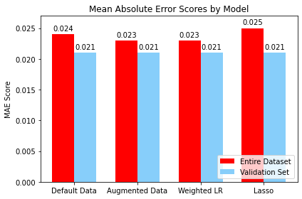

```python
x = np.arange(len(lrLabel))  # the label locations
width = 0.35  # the width of the bars

fig, ax = plt.subplots()
rects1 = ax.bar(x - width/2, lrMAE, width, label='Entire Dataset', color = 'red')
rects2 = ax.bar(x + width/2, lrValidationMAE, width, label='Validation Set', color = 'lightskyblue')

# Add some text for labels, title and custom x-axis tick labels, etc.
ax.set_ylabel('MAE Score')
ax.set_title('Mean Absolute Error Scores by Model')
ax.set_xticks(x)
ax.set_xticklabels(lrLabel)
ax.set_ylim(0, 0.027)
ax.legend(loc='lower right')


def autolabel(rects):
    """Attach a text label above each bar in *rects*, displaying its height."""
    for rect in rects:
        height = rect.get_height()
        ax.annotate('{}'.format(height),
                    xy=(rect.get_x() + rect.get_width() / 2, height),
                    xytext=(0, 3),  # 3 points vertical offset
                    textcoords="offset points",
                    ha='center', va='bottom')


autolabel(rects1)
autolabel(rects2)

fig.tight_layout()

plt.show()
```

##### Modeling - Other ML

```python
# Different Models to test
reg = LinearRegression()
rf = RandomForestRegressor()
svmTest = svm.LinearSVR(max_iter=100000000)
GradBoost = GradientBoostingRegressor(random_state=0)
lasso2 = linear_model.Lasso(alpha=0.0002268128333327706)

models = [reg, lasso2, rf, svmTest, GradBoost]
labels = ['OLS Regression','Lasso', 'Random Forest', 'Support Vector Regressor', 'Gradient Boost']


score_list =[]
rmse_val1 = []


for i, model in enumerate(models):

    model.fit(X_train, y_train)
    pred=model.predict(X_test) #make prediction on test set
    error = sqrt(mean_squared_error(y_test,pred)) #calculate rmse
    rmse_val1.append(round(error, 3)) #store rmse values
    score = model.score(X_test, y_test)
    score_list.append(round(score, 3))
    print(f'{model} score: {score}')
```

```
LinearRegression() score: 0.28378337757155037
Lasso(alpha=0.0002268128333327706) score: 0.3363427385368609
RandomForestRegressor() score: 0.32504048286194154
LinearSVR(max_iter=100000000) score: 0.37173454706114495
GradientBoostingRegressor(random_state=0) score: 0.32511467175200737
```

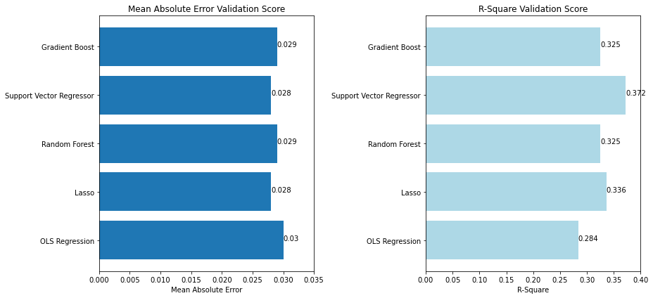

```python
import matplotlib.pyplot as plt

#labels = ['OLS Regression','Random Forest', 'Support Vector Regressor', 'Gradient Boost' , 'Lasso']
fig, axs = plt.subplots(1,2,figsize=(13,6))

axs[0].barh(labels, rmse_val1)
axs[0].set_xlim(0, 0.035)


for index, value in enumerate(rmse_val1):
    axs[0].text(value, index,  str(value))


axs[1].barh(labels, score_list, color = 'lightblue')
axs[1].set_xlim(0, 0.4)


for index, value in enumerate(score_list):
    axs[1].text(value, index,
             str(value))

axs[0].set(xlabel= 'Mean Absolute Error', title='Mean Absolute Error Validation Score')
axs[1].set(xlabel= 'R-Square', title='R-Square Validation Score')

plt.tight_layout()


plt.show()
```

```python
#### Final SVR Predictions
svmScore = svm.LinearSVR(max_iter=100000000)
svmScore.fit(X, y)
svmScore.score(X, y)
```

```
0.41545194768448845
```

```python
SVRpredictions = svmScore.predict(X)
final = fg
final['Predictions'] = SVRpredictions
final = final[['playerid', 'Name', 'Predictions']]
```

##### Misc Datasubsets used

```python
# Dataset for training only on observations with more than 50 AB's

dfAB = df[df['MarApr_AB'] > 50]
yAB = dfAB['FullSeason_AVG']
XAB = dfAB.drop(['FullSeason_AVG', 'playerid', 'Name', 'Team'], axis=1)

XAB_train, XAB_test, yAB_train, yAB_test = train_test_split(XAB, yAB, test_size=0.2, random_state=50)
```

```python
sub = X[['MarApr_K%', 'MarApr_BABIP', 'MarApr_AVG', 'Pull%', 'Cent%', 'Oppo%','Soft%', 'Med%', 'Hard%']]
sub['batted'] = 1-sub['MarApr_K%']
sub['Soft%'] = sub['batted'] * sub['Soft%']
sub['Med%'] = sub['batted'] * sub['Med%']
sub['Hard%'] = sub['batted'] * sub['Hard%']


reg = LinearRegression().fit(sub, y)
reg.score(sub, y)
```

```
0.36366010857816244
```

```python
reg = LinearRegression().fit(sub, y)
reg.score(sub, y)

CV = cross_val_score(reg, sub, y, scoring='r2', cv=cv, n_jobs=-1)
round(sum(CV)/len(CV), 3)
```

```
0.265
```

```python
# Smoothed Batting Average
Xs = X
avg = Xs['MarApr_AVG'].mean()
Xs['MarApr_AVG'] = Xs['MarApr_AVG']*.75+avg*.75

reg = LinearRegression().fit(Xs, y)
print(f'Entire Dataset Score: {reg.score(Xs, y)}')

reg = LinearRegression().fit(Xs, y)
reg.score(Xs, y)

CV = cross_val_score(reg, Xs, y, scoring='r2', cv=cv, n_jobs=-1)
round(sum(CV)/len(CV), 3)
```

```
Entire Dataset Score: 0.4637466512317324
```

```
0.254
```